# Fig-4C_OEexp_photoreceptor

Author

Andrea Mariossi

# Photoreceptor Overexpression: Opsin2 via Opsin1 Enhancer

- **Inputs** come either from my local folder or from the repository’s folder (when downloaded from GitHub).
- **Outputs** of GitHub are written to a new local folder named `output_rerun/`

## Configuration

```r
################################################################################
# ---- Configuration ----
################################################################################

pick_pipeline <- "my_local"  # "my_local" or "github"

# ---- My paths (inputs + outputs) ----
file_path <- "/Users/andrea/Library/CloudStorage/GoogleDrive-andrea.mariossi@gmail.com/My Drive/4.paper_archive/2025_thyroid_pathway_&_metamorphosis/04.SciAdv_rev/source_data"

# ---- Pipeline switch ----
if (pick_pipeline == "my_local") {

  # Inputs from my local folder
  data_dir <- file_path
  out_dir  <- file.path(file_path, "output")
  save_outputs <- TRUE

} else if (pick_pipeline == "github") {

  # ---- GitHub repo paths ----
  # By opening `thyroid_hormone_ciona.Rproj` in RStudio, `here()` finds the project root
  repo_dir <- here::here()

  # Fallback: if you downloaded the repo as a zip and unzipped it
  if (!dir.exists(file.path(repo_dir, "data"))) {
    repo_dir_try <- normalizePath(path.expand("~/Downloads/thyroid_hormone_ciona-main"), mustWork = FALSE)
    if (dir.exists(file.path(repo_dir_try, "data"))) {
      repo_dir <- repo_dir_try
    } else {
      stop("Cannot find repo 'data/' folder.\n",
           "  → Open the .Rproj file in RStudio, OR\n",
           "  → Set working directory to repo root with setwd(), OR\n",
           "  → Unzip thyroid_hormone_ciona-main.zip and update the path above.")
    }
  }

  data_dir <- file.path(repo_dir, "data")
  out_dir  <- file.path(repo_dir, "output_rerun")
  save_outputs <- TRUE

  # Uncomment line below to NOT save outputs when running from GitHub:
  # save_outputs <- FALSE
}

# ---- Path helper functions ----
dpath <- function(...) file.path(data_dir, ...)
opath <- function(...) file.path(out_dir, ...)

# Only create output dir when actually saving
if (save_outputs) dir.create(out_dir, showWarnings = FALSE, recursive = TRUE)

# ---- Configuration summary ----
message("─────────────────────────────────────────")
message("Pipeline: ", pick_pipeline)
message("Data dir (inputs): ", data_dir)
if (exists("repo_dir")) message("Repo dir: ", repo_dir)
message("Save outputs: ", save_outputs)
if (save_outputs) message("Output dir: ", out_dir)
message("─────────────────────────────────────────")

################################################################################
# ---- Theme & Style ----
################################################################################

custom_theme <- function() {
  theme(
    axis.ticks = element_line(linewidth = 0.5),
    axis.ticks.length = unit(0.09, "cm"),
    legend.key.height = unit(20, "pt"),
    axis.line = element_blank(),
    panel.border = element_rect(colour = "black", fill = NA, linewidth = 1),
    panel.background = element_blank(),
    plot.background = element_blank(),
    panel.grid.major = element_blank(),
    panel.grid.minor = element_blank(),
    legend.background = element_blank(),
    legend.box.background = element_blank(),
    legend.key = element_blank(),
    strip.background = element_blank()
  )
}

# If using Arial font (optional)
# library(showtext)
# library(sysfonts)
# sysfonts::font_add("Arial", regular = "/Library/Fonts/Arial.ttf")  # macOS
# # sysfonts::font_add("Arial", regular = "C:/Windows/Fonts/arial.ttf")  # Windows
# showtext_auto()
# theme_set(theme_pubr(base_size = 13, base_family = "Arial") + custom_theme())

theme_set(theme_pubr(base_size = 13, base_family = "sans") + custom_theme())

# Extra styling
no_legend <- theme(legend.position = "none")
axis_text_45 <- theme(axis.text.x = element_text(angle = 45, vjust = 1, hjust = 1))

# ---- color palette ----
status_colors <- c(Attached = "#1f7070", Swimming = "gray70")
status_colors <- c(Attached = "#55a2a1", Swimming = "gray70")
status_colors <- c(Attached = "#384860", Swimming = "gray70")

# ---- pretty p-values for kable ----
format_pvalues <- function(df) {
  df %>%
    mutate(across(
      any_of(c("p.value", "p.value.x", "p.value.y", "adj.p.value")),
      ~ case_when(
        . < 0.001 ~ format(., scientific = TRUE, digits = 2),
        TRUE ~ as.character(round(., 4))
      )
    ))
}
```

## Data Loading

```r
# Read and preprocess data
overexp_file <- dpath("12_photoreceptor_overexpression_opsin2.xlsx")
stopifnot(file.exists(overexp_file))

# read and preprocess data
opsn1_opsin2.df <- read_excel(overexp_file) %>%
  slice(1:10)  # line 11 is annotation reporter

opsn1_opsin2.df %>%
  kable(caption = "Raw data") %>%
  kable_styling(bootstrap_options = c("striped", "hover"))
```

Raw data

| condition | bioRep | swimming_larvae | attached_larvae |
| --- | --- | --- | --- |
| lacz | 1 | 60 | 21 |
| lacz | 2 | 43 | 24 |
| lacz | 3 | 48 | 7 |
| lacz | 4 | 24 | 16 |
| lacz | 5 | 65 | 16 |
| opsin2 | 1 | 19 | 94 |
| opsin2 | 2 | 22 | 51 |
| opsin2 | 3 | 39 | 56 |
| opsin2 | 4 | 23 | 44 |
| opsin2 | 5 | 60 | 41 |

## Descriptive Info

```r
# Data Processing
################################################################################

# percentages per replicate
opsn1_opsin2.tidy <- opsn1_opsin2.df %>%
  mutate(total_larvae = swimming_larvae + attached_larvae) %>%
  pivot_longer(cols = c(attached_larvae, swimming_larvae), names_to = "status",values_to = "count") %>%
  group_by(condition, bioRep) %>%
  mutate(percent = round(count * 100 / sum(count), 1)) %>%  # % per replicate
  ungroup()

# summarize per condition
opsn1_opsin2_condition.tidy <- opsn1_opsin2.df %>%
  mutate(total_larvae = swimming_larvae + attached_larvae) %>%
  group_by(condition) %>%
  summarise(attached = sum(attached_larvae),
            not_attached = sum(swimming_larvae),
            total = sum(total_larvae),
            n_replicates = n()
            ) %>%
  pivot_longer(cols = c(attached, not_attached),
                names_to = "status",
                values_to = "count"
              ) %>%
  mutate(percent = count / total * 100)

# summary data: mean and SE for each segment
opsn1_opsin2_summary.df <- opsn1_opsin2.tidy %>%
  group_by(condition, status) %>%
  summarise(mean_percent = mean(percent),
            se = sd(percent) / sqrt(n()),
            .groups = "drop"
          ) %>%
  arrange(condition, status) %>%
  # calculate cumulative y-position for error bars
  group_by(condition) %>%
  arrange(condition, desc(status)) %>%  # stacking order
  mutate( y_cumulative = cumsum(mean_percent),  # top of each segment
          y_start = y_cumulative - mean_percent  # bottom of each segment
        )

opsn1_opsin2_summary.df %>%
  kable(caption = "Summary statistics") %>%
  kable_styling(bootstrap_options = c("striped", "hover"))
```

Summary statistics

| condition | status | mean_percent | se | y_cumulative | y_start |
| --- | --- | --- | --- | --- | --- |
| lacz | swimming_larvae | 73.16 | 5.019223 | 73.16 | 0.00 |
| lacz | attached_larvae | 26.84 | 5.019223 | 100.00 | 73.16 |
| opsin2 | swimming_larvae | 36.34 | 6.997614 | 36.34 | 0.00 |
| opsin2 | attached_larvae | 63.66 | 6.997614 | 100.00 | 36.34 |

```r
# # clean tidy a single working analysisdataset
# opsn1_opsin2_analysis <- opsn1_opsin2.df %>%
#   mutate(
#     total_larvae = swimming_larvae + attached_larvae,
#     prop_attached = attached_larvae / total_larvae
#   )
```

## QC visualization

- ```r
  # QC Visualization
  ################################################################################

  # ---- Check sample size distribution ----

  # Summary by replicate
  replicate_summary <- opsn1_opsin2.df %>%
    mutate(total_larvae = swimming_larvae + attached_larvae) %>%
    group_by(condition, bioRep) %>%
    summarise(
      n_larvae = sum(total_larvae),
      prop_attached = sum(attached_larvae) / sum(total_larvae),
      .groups = "drop"
    )

  replicate_summary %>%
    kable(caption = "Sample sizes by biological replicate") %>%
    kable_styling(bootstrap_options = c("striped", "hover"))
  ```

  Sample sizes by biological replicate

  | condition | bioRep | n_larvae | prop_attached |
  | --- | --- | --- | --- |
  | lacz | 1 | 81 | 0.2592593 |
  | lacz | 2 | 67 | 0.3582090 |
  | lacz | 3 | 55 | 0.1272727 |
  | lacz | 4 | 40 | 0.4000000 |
  | lacz | 5 | 81 | 0.1975309 |
  | opsin2 | 1 | 113 | 0.8318584 |
  | opsin2 | 2 | 73 | 0.6986301 |
  | opsin2 | 3 | 95 | 0.5894737 |
  | opsin2 | 4 | 67 | 0.6567164 |
  | opsin2 | 5 | 101 | 0.4059406 |

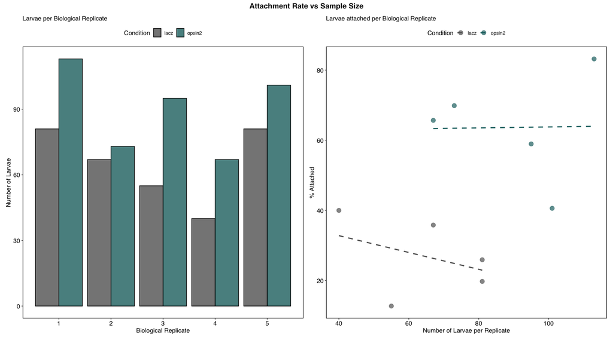

  ```r
  # Visualize sample size distribution
  p_sizeDistribution <- ggplot(replicate_summary, aes(x = bioRep, y = n_larvae, fill = condition)) +
    geom_col(position = "dodge", color = "black", alpha = 0.8) +
    scale_fill_manual(values = c("lacz" = "#636363", "opsin2" = "#1f7070")) +
    labs(
      subtitle = "Larvae per Biological Replicate",
      x = "Biological Replicate",
      y = "Number of Larvae",
      fill = "Condition"
    ) +
    custom_theme()

  # proportion vs sample size (to see if small samples behave differently)
  p_sizeProp <- ggplot(replicate_summary, aes(x = n_larvae, y = prop_attached * 100, color = condition)) +
    geom_point(size = 4, alpha = 0.7) +
    geom_smooth(method = "lm", se = FALSE, linetype = "dashed") +
    scale_color_manual(values = c("lacz" = "#636363", "opsin2" = "#1f7070")) +
    labs(
      subtitle = "Larvae attached per Biological Replicate",
      x = "Number of Larvae per Replicate",
      y = "% Attached",
      color = "Condition"
    ) +
    custom_theme()

  p_sizeDistribution + p_sizeProp +
    plot_annotation(title = "Attachment Rate vs Sample Size") &
    theme(plot.title = element_text(hjust = 0.5, face = "bold"))
  ```

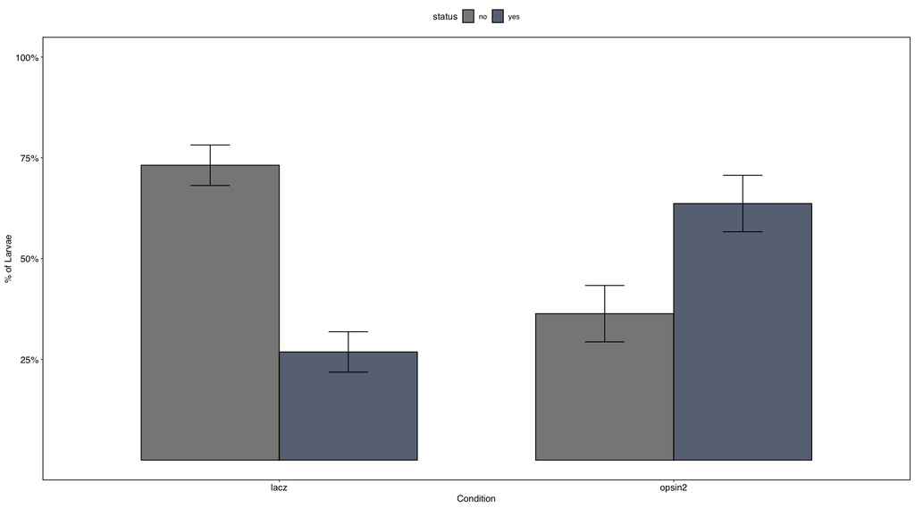

```r
# QC Visualization
################################################################################

# https://stackoverflow.com/questions/42329858/stacked-percentage-barplot-with-error-bars-in-ggplot2

# ---- side-by-side comparison ----
opsn1_opsin2_summary.df %>%
  mutate(status = factor(status, levels = c("swimming_larvae", "attached_larvae"))) %>%
  ggplot(aes(x = condition, y = mean_percent, fill = status)) +
  geom_col(position = "dodge", width = 0.7, alpha = 0.8, color = "black") +
  geom_errorbar(
    aes(ymin = mean_percent - se, ymax = mean_percent + se),
    position = position_dodge(width = 0.7),
    width = 0.2
  ) +
  scale_fill_manual(
    values = c("attached_larvae" = "#384860", "swimming_larvae" = "gray40"),
    labels = c("no", "yes")
  ) +
  scale_y_continuous(
    labels = scales::percent_format(scale = 1),
    breaks = c(25, 50, 75, 100),
    limits = c(0, 100)
  ) +
  labs(y = "% of Larvae", x = "Condition") +
  custom_theme()
```

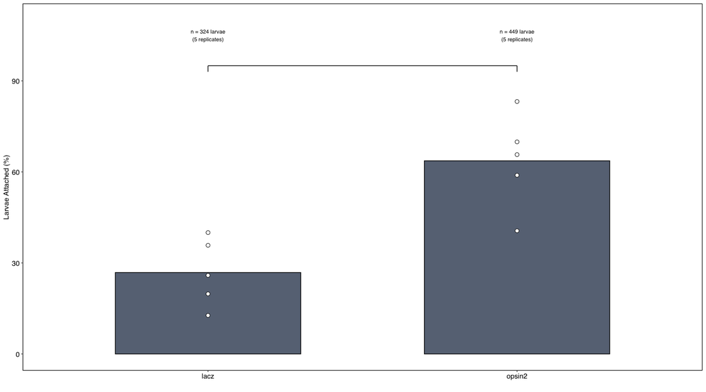

```r
# ---- single bar plot ----
replicate_data <- opsn1_opsin2.tidy %>%
  filter(status == "attached_larvae")

ggplot() +
  # bar for mean percentage
  geom_col(
    data = opsn1_opsin2_summary.df %>% filter(status == "attached_larvae"),
    aes(x = condition, y = mean_percent),
    width = 0.6,
    fill = "#384860",
    color = "black",
    alpha = 0.8
  ) +
  # individual replicate points
  geom_point(
    data = replicate_data,
    aes(x = condition, y = percent),
    size = 3,
    shape = 21,
    fill = "white",
    color = "black"
  ) +
  # sample size labels
  geom_text(data = opsn1_opsin2_condition.tidy %>% filter(status == "attached") %>% distinct(),
    aes(x = condition, y = 105,label = paste0("n = ", total, " larvae\n(", n_replicates, " replicates)")), size = 3.5) +
  # significance bracket
  annotate("segment", x = 1, xend = 2, y = 95, yend = 95, linewidth = 0.6) +
  annotate("segment", x = 1, xend = 1, y = 95, yend = 93, linewidth = 0.6) +
  annotate("segment", x = 2, xend = 2, y = 95, yend = 93, linewidth = 0.6) +
  labs(x = "", y = "Larvae Attached (%)") +
  custom_theme() +
  coord_cartesian(ylim = c(0, 110))
```

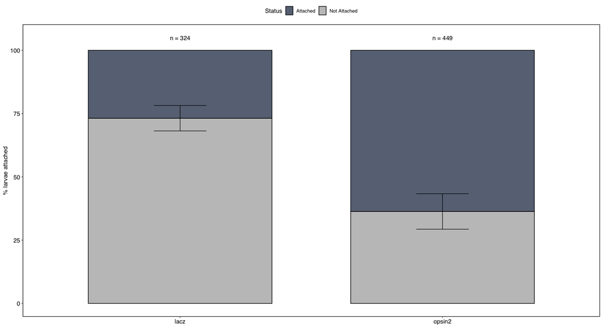

```r
# ---- stacked plot ----
# this use stardard CI
overExp_plot_onlyLower <- ggplot(
  opsn1_opsin2_summary.df,
  aes(x = condition, y = mean_percent, fill = status)
) +
  # stacked bars (mean %)
  geom_col(width = 0.7, alpha = 0.8, color = "black") +
  # segment-specific error bars
  geom_errorbar(
    data = subset(opsn1_opsin2_summary.df, status == "attached_larvae"),
    aes(
      ymin = y_start - se,  # at the boundary
      ymax = y_start + se
    ),
    width = 0.2,
    color = "black",
    linewidth = 0.5,
    position = position_dodge(width = 0)
  ) +
  geom_text(
    data = opsn1_opsin2_condition.tidy %>% distinct(condition, total),
    aes(x = condition, y = 105, label = paste0("n = ", total)),
    inherit.aes = FALSE
  ) +
  scale_fill_manual(
    values = c("attached_larvae" = "#384860", "swimming_larvae" = "gray70"),
    labels = c("Attached", "Not Attached")
  ) +
  labs(x = "", y = "% larvae attached", fill = "Status") +
  custom_theme() +
  theme(legend.position = "top", panel.grid.major.x = element_blank())

overExp_plot_onlyLower
```

## Statistical analysis

### model specification - simple

```r
# Statistical Analysis - Simple Tests
################################################################################

# ============================================================================
# simple analysis: Attachment rates (yes/no)
# ---- simple analysis: attachment rates (yes/no) ----

# calculate totals per condition
summary_stats <- opsn1_opsin2.tidy %>%
  filter(status == "attached_larvae") %>%
  group_by(condition) %>%
  summarize(
    n_replicates = n(),
    attached = sum(count),
    total = sum(total_larvae),
    percent = (attached / total) * 100
  )

summary_stats %>%
  kable(caption = "Summary statistics by condition") %>%
  kable_styling(bootstrap_options = c("striped", "hover"))
```

Summary statistics by condition

| condition | n_replicates | attached | total | percent |
| --- | --- | --- | --- | --- |
| lacz | 5 | 84 | 324 | 25.92593 |
| opsin2 | 5 | 286 | 449 | 63.69710 |

```r
# Effect size (Cohen's h for proportions)
p1 <- summary_stats$percent[1] / 100  # lacz
p2 <- summary_stats$percent[2] / 100  # opsin2
cohens_h <- 2 * (asin(sqrt(p2)) - asin(sqrt(p1)))
cat("Cohen's h =", round(cohens_h, 3), "\n")
```

```
Cohen's h = 0.78
```

```r
#-------------------------------------------------------------------------------
# Pooled across bioRep
# Fisher’s exact test (better for small samples) vs chisq.test for larger samples
#-------------------------------------------------------------------------------

contingency_table <- opsn1_opsin2.df %>%
  mutate(total_larvae = swimming_larvae + attached_larvae) %>%
  group_by(condition) %>%
  summarise(
    attached = sum(attached_larvae),
    swimming = sum(swimming_larvae)
  ) %>%
  column_to_rownames("condition") %>%
  as.matrix()

fisher_result <- fisher.test(contingency_table) # ==>Odds Ratio
print(fisher_result)
```

```
    Fisher's Exact Test for Count Data

data:  contingency_table
p-value < 2.2e-16
alternative hypothesis: true odds ratio is not equal to 1
95 percent confidence interval:
 0.1437530 0.2762586
sample estimates:
odds ratio
 0.1999128
```

```r
# effect size: odds ratio
or <- (contingency_table[2, 1] * contingency_table[1, 2]) /
  (contingency_table[1, 1] * contingency_table[2, 2])

cat("\nOdds Ratio (opsin2/lacz):", round(or, 2), "\n")
```

```
Odds Ratio (opsin2/lacz): 5.01
```

```r
cat("Interpretation: opsin2 larvae are", round(or, 1),
    "× more likely to attach than lacz\n")
```

```
Interpretation: opsin2 larvae are 5 × more likely to attach than lacz
```

```r
# ============================================================================
# This is Chi-square test ==> same type of taste different n as input
# chi_test <- chisq.test(contingency_table)
# cat("χ² =", round(chi_test$statistic, 2), "\n")
# cat("df =", chi_test$parameter, "\n")
# cat("P-value:", format.pval(chi_test$p.value, digits = 3), "\n")

#-------------------------------------------------------------------------------

# this test doesnst really account for replicate variability, ill model with logistic regression model (binomial outcome: attached vs. total larvae)
```

### Binomial GLMM with Random Effects

Electroporations are performed back-to-back for both the control (**LacZ**) and the experimental group (**Opsin2**). Embryos are from a pool of 4–5 adults. This process is repeated across five independent days/ Ciona shipments (biological replicates). We use a **Binomial Logistic Mixed Model (GLMM)** to account for the fact that larvae within the same batch are likely to be similar to each other than to those in other batches (**intra-class correlation**).

The model is defined as:
$$\operatorname{logit}(P(Y_{ij}=1)) = \beta_0 + \beta_1 \cdot \text{Condition}_j + u_i$$

- $Y_{ij}$: The binary outcome for the $j$-th larva in the $i$-th replicate.
- $\beta_0$: The fixed intercept, representing the baseline probability).
- $\beta_1$: The fixed effect representing the impact of **Opsin2** overexpression relative to the LacZ control.
- $u_i \sim N(0, \sigma^2)$: The random intercept for the $i$-th biological replicate, capturing batch-specific baseline shifts.

```r
# ============================================================================
# Research Question:
# Does overexpression of Opsin2 (via Opsin1 enhancer) increase larval
# attachment compared to LacZ control?
#
# Statistical Model:
# logit(P(attached)) = β0 + β1·Condition + u_bioRep
# where u_bioRep ~ N(0, σ²) accounts for electroporation batches
#
# H0: β1 = 0 (no difference between opsin2 and lacz)
# ============================================================================
```

```r
#-------------------------------------------------------------------------------
# Binomial GLMM with random effects:
#-------------------------------------------------------------------------------

# ---- fit GLMM with random effects ----
glmer_model <- opsn1_opsin2.df %>%
  mutate(total_larvae = swimming_larvae + attached_larvae) %>%
  glmer(
    cbind(attached_larvae, swimming_larvae) ~ condition + (1 | bioRep),
    family = binomial,
    data = .
  )

# # manually extract results
# glmer_summary <- summary(glmer_model)
# p_value <- coef(glmer_summary)[2, "Pr(>|z|)"]
# glmer_fixef <- fixef(glmer_model) #fixed_effects
# random_effects <- VarCorr(glmer_model) # random_effects
#
# or_value <- exp(fixef(glmer_model)["conditionopsin2"]) # get odds ratios
# glmer_confint <- confint(glmer_model, method = "Wald", parm = "beta_") # confidence intervals for odds ratios
# ci_profile <- confint(glmer_model, method = "profile", parm = "beta_") # Profile likelihood CIs (more accurate but slower)


# cat("\nGLMM Results:\n")
# cat("\nP-value for opsin2 vs lacz:", format.pval(coef(glmer_summary)["conditionopsin2", "Pr(>|z|)"], digits = 3), "\n")
# cat("\nP-value for odds ratios:", exp(fixef(glmer_model)) , "\n")
# cat("\nP-value Range CI:", confint(glmer_model, method = "Wald", parm = "beta_"), "\n")

# Tidy results
glmer_results <- broom.mixed::tidy(glmer_model, effects = "fixed", conf.int = TRUE) %>%
  mutate(
     # transform log-odds to odds ratios
    odds_ratio = exp(estimate),
    conf.low = exp(conf.low),
    conf.high = exp(conf.high),
    model_type = "GLMM",
    # format p-values nicely
    p.value_char = case_when(p.value < 0.001 ~ "< 0.001",TRUE ~ as.character(round(p.value, 4)))
  )

glance(glmer_model) %>%
  kable(caption = "GLMM model fit statistics") %>%
  kable_styling(bootstrap_options = c("striped", "hover"))
```

GLMM model fit statistics

| nobs | sigma | logLik | AIC | BIC | deviance | df.residual |
| --- | --- | --- | --- | --- | --- | --- |
| 10 | 1 | -38.28339 | 82.56678 | 83.47454 | 16.65603 | 7 |

```r
glmer_results %>%
  kable(caption = "Binomial GLMM results for larval attachment (Condition + (1|bioRep))",
    align = "lcccccc",digits = 3,) %>%
  kable_styling(bootstrap_options = c("striped", "hover", "condensed"),full_width = FALSE,position = "center" ) %>%
  row_spec(0, bold = TRUE, background = "#F2F2F2") %>%
  footnote(general = "Model fit: glmer(cbind(attached, swimming) ~ condition + (1|bioRep), family = binomial). Reference level for condition is 'lacz'.")
```

Binomial GLMM results for larval attachment (Condition + (1|bioRep))

| effect | term | estimate | std.error | statistic | p.value | conf.low | conf.high | odds_ratio | model_type | p.value_char |
| --- | --- | --- | --- | --- | --- | --- | --- | --- | --- | --- |
| fixed | (Intercept) | -1.094 | 0.251 | -4.365 | 0 | 0.205 | 0.547 | 0.335 | GLMM | < 0.001 |
| fixed | conditionopsin2 | 1.708 | 0.168 | 10.185 | 0 | 3.974 | 7.669 | 5.520 | GLMM | < 0.001 |

Note:  
Model fit: glmer(cbind(attached, swimming) ~ condition + (1|bioRep), family = binomial). Reference level for condition is 'lacz'.

```r
cat(sprintf("Opsin2 larvae are %.1fx more likely to attach than LacZ controls\n", glmer_results$odds_ratio[2]))
```

```
Opsin2 larvae are 5.5x more likely to attach than LacZ controls
```

```r
cat(sprintf("This corresponds to a %.1f%% increase in odds of attachment\n", (glmer_results$odds_ratio[2] - 1) * 100))
```

```
This corresponds to a 452.0% increase in odds of attachment
```

```r
cat(sprintf("95%% CI: [%.3f, %.3f]",glmer_results$conf.low[2],glmer_results$conf.high[2]))
```

```
95% CI: [3.974, 7.669]
```

### Model comparison (GLM vs GLMM)

To ensure the statistical model fits the data appropriately, compare a generalized linear model (GLM) and a generalized linear mixed model (GLMM) using an ANOVA-based likelihood ratio test (LTR). This test evaluates whether adding a random intercept ($u_i$) significantly improves model fit.

Null Hypothesis ($H_0$): The variance of the random effect is zero ($\sigma^2 = 0$). A GLM is sufficient. Alternative Hypothesis ($H_1$): The variance is significantly greater than zero. A GLMM is required, the random intercept is necessary to account for replicate variance.

Variance Analysis: If the variance of the random effect ($u_i$) is approximately 0, the GLMM essentially collapses into a GLM. This usually occurs when the effect size is massive and highly consistent across all experimental batches.

```r
# Model GLM
################################################################################

# Fit GLM without random effects
glm_model <- glm(
  cbind(attached_larvae, swimming_larvae) ~ condition,
  family = binomial,
  data = opsn1_opsin2.df
  )

# tidy model results
glm_results <- broom.mixed::tidy(glm_model, conf.int = TRUE) %>%
  mutate(
    odds_ratio = exp(estimate),
    conf.low = exp(conf.low),
    conf.high = exp(conf.high),
    model_type = "GLM"
  )

glm_results %>%
  kable(caption = "GLM Results") %>%
  kable_styling(bootstrap_options = c("striped", "hover"))
```

GLM Results

| term | estimate | std.error | statistic | p.value | conf.low | conf.high | odds_ratio | model_type |
| --- | --- | --- | --- | --- | --- | --- | --- | --- |
| (Intercept) | -1.049822 | 0.1267731 | -8.281109 | 0 | 0.2715505 | 0.4466523 | 0.350000 | GLM |
| conditionopsin2 | 1.612064 | 0.1603212 | 10.055210 | 0 | 3.6742911 | 6.8912464 | 5.013146 | GLM |

```r
#-------------------------------------------------------------------------------
# Model Comparison (GLM vs GLMM)
#-------------------------------------------------------------------------------

# Combine extract model results for comparison
model_comparison <- bind_rows(glm_results, glmer_results) %>%
  filter(term == "conditionopsin2")

# Likelihood ratio test  # to test significance of random effects
lr_test <- anova(glm_model, glmer_model)

lr_test %>%
  kable(caption = "GLMM vs GLM Results") %>%
  kable_styling(bootstrap_options = c("striped", "hover"))
```

GLMM vs GLM Results

|  | Df | Deviance | Resid. Df | Resid. Dev | Pr(>Chi) |
| --- | --- | --- | --- | --- | --- |
| NULL | NA | NA | 9 | 170.82727 | NA |
| condition | 1 | 111.0418 | 8 | 59.78552 | 0 |

```r
# Display comparison
cat("=== Model Comparison ===\n")
```

```
=== Model Comparison ===
```

```r
cat("Likelihood Ratio Test:\n")
```

```
Likelihood Ratio Test:
```

```r
print(lr_test)
```

```
Analysis of Deviance Table

Model: binomial, link: logit

Response: cbind(attached_larvae, swimming_larvae)

Terms added sequentially (first to last)

          Df Deviance Resid. Df Resid. Dev  Pr(>Chi)
NULL                          9    170.827
condition  1   111.04         8     59.786 < 2.2e-16 ***
---
Signif. codes:  0 '***' 0.001 '**' 0.01 '*' 0.05 '.' 0.1 ' ' 1
```

```r
cat("AIC:\n")
```

```
AIC:
```

```r
print(AIC(glm_model, glmer_model))
```

```
            df       AIC
glm_model    2 108.90512
glmer_model  3  82.56678
```

```r
cat("\nOdds Ratio Comparison:\n")
```

```
Odds Ratio Comparison:
```

```r
print(model_comparison[, c("model_type", "odds_ratio", "conf.low", "conf.high", "p.value")])
```

```
# A tibble: 2 × 5
  model_type odds_ratio conf.low conf.high  p.value
  <chr>           <dbl>    <dbl>     <dbl>    <dbl>
1 GLM              5.01     3.67      6.89 8.71e-24
2 GLMM             5.52     3.97      7.67 2.31e-24
```

- Consistency: GLM and GLMM give the same takeaway—opsin2 increases attachment a lot (OR ≈ 5–5.5; same direction and similar magnitude).
- Model fit: The GLMM fits much better than the GLM (AIC 82.6 vs 108.9; ΔAIC ≈ 26), supporting accounting for bioRep clustering.
- Precision: The GLMM is a bit more conservative. CIs are slightly wider because it models replicate-to-replicate variability.

### Results table

```r
# Simplified results table
results_table <- data.frame(
  Analysis = c(
    "Fisher's Exact Test (Pooled)",
    "Binomial GLM (Fixed Effects)",
    "Binomial GLMM (Mixed Effects)",
    "Effect Size (Cohen's h)"
  ),
  Result = c(
    sprintf("OR = %.2f, p < 0.001", or),
    sprintf("OR = %.2f (95%% CI: %.2f-%.2f), p < 0.001",
            exp(coef(glm_model)[2]),
            exp(confint(glm_model)[2,1]),
            exp(confint(glm_model)[2,2])),
    sprintf("OR = %.2f (95%% CI: %.2f-%.2f), p < 0.001",
            exp(fixef(glmer_model)[2]),
            exp(confint(glmer_model, method = "Wald")[2,1]),
            exp(confint(glmer_model, method = "Wald")[2,2])),
    sprintf("h = %.3f", cohens_h)
  ),
  Interpretation = c(
    "Pooled analysis ignoring replicates",
    "Fixed effects only. Accounts for overdispersion, not clustering",
    "Accounts for replicate variability (primary)",
    "Standardized difference between proportions"
  ),
  Source = c(
    "fisher.test() on pooled contingency table",
    "glm() with binomial family",
    "glmer() with (1|bioRep)",
    "2*(asin(√p₂)-asin(√p₁))"
  )
)

# Display table
results_table %>%
  kable(
    caption = "Statistical Analysis Results",
    align = c("l", "l", "l", "l")
  ) %>%
  kable_styling(
    bootstrap_options = c("striped", "hover", "condensed"),
    full_width = FALSE
  ) %>%
  row_spec(3, bold = TRUE, background = "#E8F4F8") %>%  # Highlight GLMM
  column_spec(1, width = "25%") %>%
  column_spec(2, width = "25%") %>%
  column_spec(3, width = "30%") %>%
  column_spec(4, width = "20%") %>%
  footnote(
    general = "GLMM: Generalized Linear Mixed Model with random intercept for biological replicate (1|bioRep).",
    general_title = "Note:",
    footnote_as_chunk = TRUE
  )
```

Statistical Analysis Results

[output not shown]

Note: GLMM: Generalized Linear Mixed Model with random intercept for biological replicate (1|bioRep).

## Comparison confidence interval methods

Comparison of confidence interval methods: - Normal CIs are symmetric (assumes unbounded data) - Wilson CIs are asymmetric (correct for proportions)

```r
# Confidence Intervals
################################################################################

# Single calculation with Wilson CIs
stats_with_ci <- opsn1_opsin2.tidy %>%
  drop_na() %>%
  filter(status == "attached_larvae") %>%
  group_by(condition) %>%
  summarize(
    n_replicates = n(),
    attached = sum(count),
    total = sum(total_larvae),
    mean_percent = mean(percent),
    .groups = "drop"
  ) %>%
  rowwise() %>%
  mutate(
    # calculate 95% Wilson CI
    wilson = list(binom.confint(attached, total, methods = "wilson")),
    wilson_low = wilson$lower * 100,
    wilson_high = wilson$upper * 100,

    # calculate 95 normal SE
    p = attached / total,
    se = sqrt(p * (1 - p) / total),
    normal_low = (p - 1.96 * se) * 100,
    normal_high = (p + 1.96 * se) * 100
  ) %>%
  ungroup() %>%
  select(-wilson)  # Remove list column after extracting values

# ---- Table comparing CI methods ----
stats_with_ci %>%
  mutate(
    wilson_text = sprintf("%.1f%% (%.1f–%.1f%%)", mean_percent, wilson_low, wilson_high),
    normal_text = sprintf("%.1f%% (%.1f–%.1f%%)", mean_percent, normal_low, normal_high)
  ) %>%
  select(condition, mean_percent, wilson_text, normal_text) %>%
  kable(caption = "Comparison of CI methods") %>%
  kable_styling(bootstrap_options = c("striped", "hover"))
```

Comparison of CI methods

| condition | mean_percent | wilson_text | normal_text |
| --- | --- | --- | --- |
| lacz | 26.84 | 26.8% (21.5–31.0%) | 26.8% (21.2–30.7%) |
| opsin2 | 63.66 | 63.7% (59.2–68.0%) | 63.7% (59.2–68.1%) |

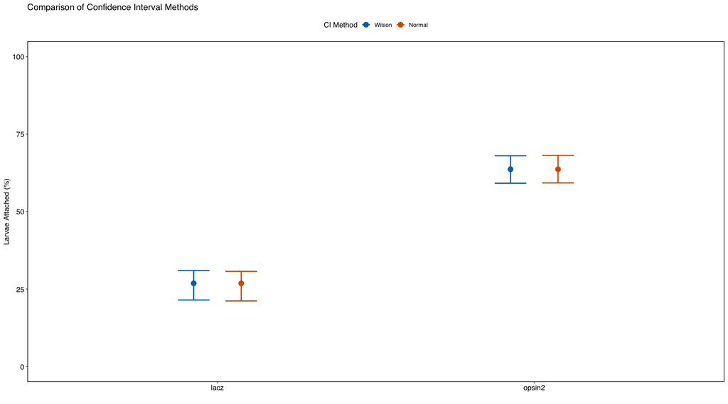

```r
#-------------------------------------------------------------------------------
# CI comparison plot
#-------------------------------------------------------------------------------

p_comparison <- stats_with_ci %>%
  select(condition, mean_percent, wilson_low, wilson_high, normal_low, normal_high) %>%
  pivot_longer(
    cols = ends_with(c("_low", "_high")),
    names_to = c("method", "bound"),
    names_pattern = "(.*)_(.*)",
    values_to = "value"
  ) %>%
  pivot_wider(names_from = bound, values_from = value) %>%
  mutate(method = factor(method, levels = c("wilson", "normal"),
                         labels = c("Wilson", "Normal"))) %>%

  ggplot(aes(x = condition, y = mean_percent, color = method)) +
  geom_point(size = 4, position = position_dodge(width = 0.3)) +
  geom_errorbar(
    aes(ymin = low, ymax = high),
    width = 0.2, linewidth = 1,
    position = position_dodge(width = 0.3)
  ) +
  scale_color_manual(values = c("Wilson" = "#0072B2", "Normal" = "#D55E00")) +
  labs(
    x = "", y = "Larvae Attached (%)", color = "CI Method",
    title = "Comparison of Confidence Interval Methods"
  ) +
  theme(legend.position = "top") +
  coord_cartesian(ylim = c(0, 100))

p_comparison
```

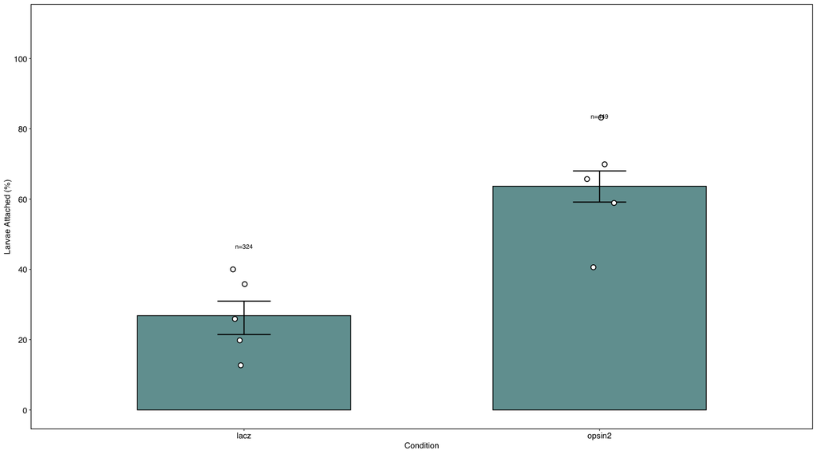

```r
#-------------------------------------------------------------------------------
# bar plot with Wilson CI and  individual point
#-------------------------------------------------------------------------------
ggplot() +
  geom_col(
    data = stats_with_ci,
    aes(x = condition, y = mean_percent),
    fill = "#1f7070", color = "black", width = 0.6, alpha = 0.7
  ) +
  geom_errorbar(
    data = stats_with_ci,
    aes(x = condition, ymin = wilson_low, ymax = wilson_high),
    width = 0.15, linewidth = 0.8, color = "black"
  ) +
  geom_point(
    data = filter(opsn1_opsin2.tidy, status == "attached_larvae"),
    aes(x = condition, y = percent),
    shape = 21, fill = "white", color = "black", size = 3, stroke = 1,
    position = position_jitter(width = 0.05, height = 0)
  ) +
  geom_text(
    data = stats_with_ci,
    aes(x = condition, y = wilson_high + 15, label = paste0("n=", total)),
    size = 3.5, vjust = 0
  ) +
  labs(y = "Larvae Attached (%)", x = "Condition") +
  scale_y_continuous(limits = c(0, 110), breaks = seq(0, 100, 20)) +
  custom_theme()
```

## Figure 4C: stacked plot with Wilson CIs

```r
# Figure 4C
################################################################################
# ---- Merge CI data with positioning info for stacked bars ----
# Rename stats_with_ci to match your naming convention + add BiCI column names
opsn1_opsin2_BiCI.df <- stats_with_ci %>%
  rename(BiCI_low = wilson_low, BiCI_high = wilson_high)


# merge CI data with positioning info
CI_data <- opsn1_opsin2_summary.df %>%
  # align status names between datasets
  mutate(status = case_when(
    status == "attached_larvae" ~ "attached",
    status == "swimming_larvae" ~ "not_attached",
    TRUE ~ status
  )) %>%
  left_join(
    opsn1_opsin2_BiCI.df %>% select(condition, BiCI_low, BiCI_high),
    by = "condition"
  ) %>%
  # calculate error bar positions on stacked bars
  mutate(
    BiCI_low_position = y_start + BiCI_low - mean_percent,
    BiCI_high_position = y_start + BiCI_high - mean_percent
  )

# CI positioning table
CI_data %>%
  select(condition, status, mean_percent, y_start, BiCI_low, BiCI_high,
         BiCI_low_position, BiCI_high_position) %>%
  kable(caption = "CI positions for error bars") %>%
  kable_styling(bootstrap_options = c("striped", "hover"))
```

CI positions for error bars

| condition | status | mean_percent | y_start | BiCI_low | BiCI_high | BiCI_low_position | BiCI_high_position |
| --- | --- | --- | --- | --- | --- | --- | --- |
| lacz | not_attached | 73.16 | 0.00 | 21.45594 | 30.96008 | -51.70406 | -42.19992 |
| lacz | attached | 26.84 | 73.16 | 21.45594 | 30.96008 | 67.77594 | 77.28008 |
| opsin2 | not_attached | 36.34 | 0.00 | 59.15039 | 68.01143 | 22.81039 | 31.67143 |
| opsin2 | attached | 63.66 | 36.34 | 59.15039 | 68.01143 | 31.83039 | 40.69143 |

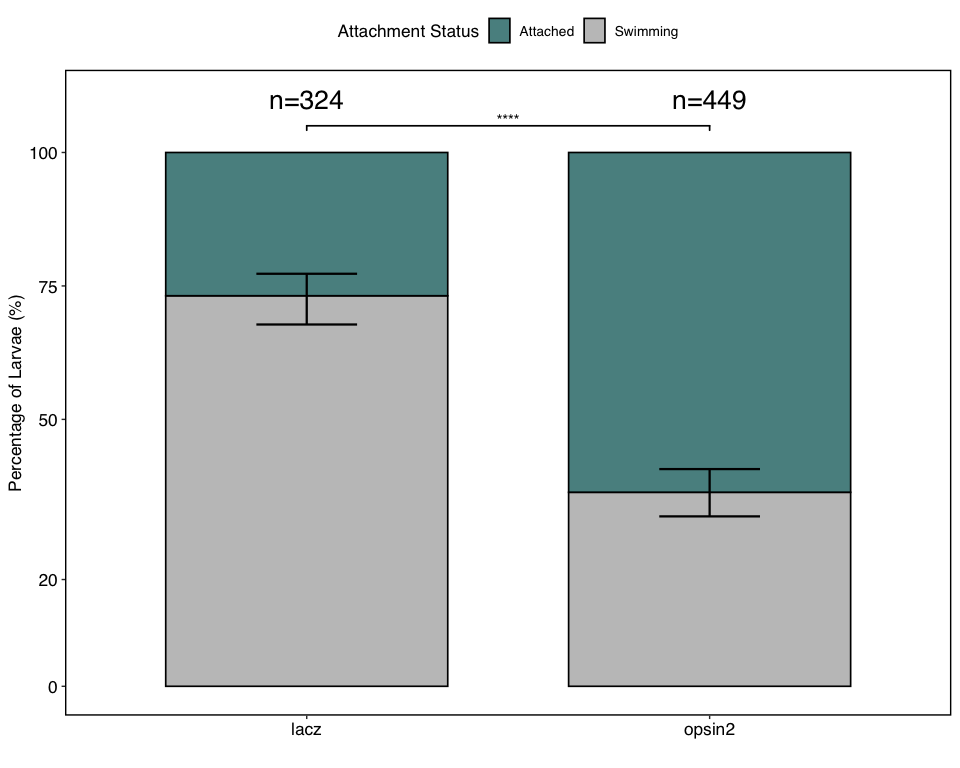

```r
# ---- create main figure ----
opsin2_plot_BiCI <- ggplot(
  opsn1_opsin2_summary.df,
  aes(x = condition, y = mean_percent, fill = status)
) +
  geom_col(width = 0.7, alpha = 0.8, color = "black") +
  # Error bars at attachment boundary
  geom_errorbar(
    data = filter(CI_data, status == "attached"),
    aes(ymin = BiCI_low_position, ymax = BiCI_high_position),
    width = 0.25, color = "black", linewidth = 0.8
  ) +
  # Sample size labels
  geom_text(
    data = opsn1_opsin2_BiCI.df,
    aes(x = condition, y = 110, label = paste0("n=", total)),
    inherit.aes = FALSE, size = 7
  ) +
  scale_fill_manual(
    values = c("attached_larvae" = "#1f7070", "swimming_larvae" = "gray70"),
    labels = c("Attached", "Swimming")
  ) +
  labs(x = "", y = "Percentage of Larvae (%)", fill = "Attachment Status") +
  coord_cartesian(ylim = c(0, 110)) +
  scale_y_continuous(breaks = c(0, 20, 50, 75, 100)) +
  # Significance brackets
  stat_pvalue_manual(
    data = data.frame(
      group1 = "lacz",
      group2 = "opsin2",
      p.signif = "****",
      status = "attached",
      y.position = 105
    ),
    label = "p.signif",
    tip.length = 0.01,
    bracket.size = 0.6
  ) +
  theme(
    legend.position = "top",
    panel.grid.major.x = element_blank()
  ) +
  custom_theme()

opsin2_plot_BiCI
```

```r
# # Figure 4C
# ################################################################################
#
# # repetitive from scratce
# # ---- calculate totals per condition ----
# attached_total.df <- opsn1_opsin2.tidy %>%
#   drop_na() %>%
#   filter(status == "attached_larvae") %>%
#   group_by(condition) %>%
#   summarize(
#     n_replicates = n(),
#     attached = sum(count),
#     total = sum(total_larvae),
#     mean_percent = mean(percent),
#     percent = (attached / total) * 100
#   )
#
# # ---- calculate wilson CIs ----
# opsn1_opsin2_BiCI.df <- attached_total.df %>%
#   rowwise() %>%
#   mutate(
#     ci = list(binom.confint(attached, total, methods = "wilson")),
#     BiCI_low = ci$lower * 100,
#     BiCI_high = ci$upper * 100
#   ) %>%
#   select(-ci)
#
#
# # merge CI data with positioning info
# CI_data <- opsn1_opsin2_summary.df %>%
#   # align status names between datasets
#   mutate(status = case_when(
#     status == "attached_larvae" ~ "attached",
#     status == "swimming_larvae" ~ "not_attached",
#     TRUE ~ status
#   )) %>%
#   left_join(
#     opsn1_opsin2_BiCI.df %>% select(-mean_percent),
#     by = c("condition")
#   ) %>%
#   # calculate error bar positions
#   mutate(
#     BiCI_low_position = y_start + BiCI_low - mean_percent,
#     BiCI_high_position = y_start + BiCI_high - mean_percent
#   )
#
# CI_data %>%
#   select(
#     condition, status, mean_percent, y_start, BiCI_low, BiCI_high,
#     BiCI_low_position, BiCI_high_position
#   ) %>%
#   kable(caption = "CI positions for error bars") %>%
#   kable_styling(bootstrap_options = c("striped", "hover"))
#
# # ---- create main figure ----
#
# opsin2_plot_BiCI <- ggplot(
#   opsn1_opsin2_summary.df,
#   aes(x = condition, y = mean_percent, fill = status)
# ) +
#   geom_col(width = 0.7, alpha = 0.8, color = "black") +  # stacked bars
#   # error bars at attachment boundary
#   geom_errorbar(
#     data = CI_data %>% filter(status == "attached"),
#     aes(ymin = BiCI_low_position, ymax = BiCI_high_position),
#     width = 0.25,
#     color = "black",
#     linewidth = 0.8
#   ) +
#   # sample size labels
#   geom_text(
#     data = opsn1_opsin2_BiCI.df %>%
#       group_by(condition) %>%
#       summarize(total = first(total)),
#     aes(x = condition, y = 110, label = paste0("n=", total)),
#     inherit.aes = FALSE,
#     size = 7
#   ) +
#   scale_fill_manual(
#     values = c("attached_larvae" = "#1f7070", "swimming_larvae" = "gray70"),
#     labels = c("Attached", "Swimming")
#   ) +
#   labs(x = "", y = "Percentage of Larvae (%)", fill = "Attachment Status") +
#   theme(
#     legend.position = "top",
#     panel.grid.major.x = element_blank()
#   ) +
#   coord_cartesian(ylim = c(0, 110)) +
#   scale_y_continuous(breaks = c(0, 20, 50, 75, 100)) +
#   # significance brackets and stars
#   stat_pvalue_manual(
#     data = data.frame(
#       group1 = "lacz",
#       group2 = c("opsin2"),
#       p.signif = c("****"),  # GLMM p-values
#       status = c("attached"),
#       y.position = c(105)
#     ),
#     label = "p.signif",
#     tip.length = 0.01,
#     bracket.size = 0.6
#   ) +
#   custom_theme()
#
# opsin2_plot_BiCI
```

## Save Plots

```r
message("\n✓ Analysis complete!")
message("Outputs saved to: ", out_dir)
message("Main figure: ", opath("main_figure.pdf"))
message("Results table: ", opath("results_summary.csv"))

# Save plots only if SAVE_OUTPUTS is TRUE
if (exists("SAVE_OUTPUTS") && SAVE_OUTPUTS) {

  # Save main figure (use your final figure object name)
  if (exists("main_figure")) {
    # Save with cowplot
    cowplot::save_plot(
      plot = main_figure,
      filename = opath("opsin2_overexpression_main.pdf"),
      base_width = 8,
      base_height = 6
    )

    # Save with CairoPDF
    CairoPDF(
      filename = opath("opsin2_overexpression_main_cairo.pdf"),
      width = 8,
      height = 6
    )
    print(main_figure)
    dev.off()
  }

  # If you have other specific plots, save them too
  if (exists("final_figure")) {
    ggsave(
      filename = opath("final_figure.pdf"),
      plot = final_figure,
      width = 8,
      height = 6,
      device = cairo_pdf
    )
  }

  message("\nPlots saved to: ", out_dir)
}
```